# Bandwidth Selection For Local Polynomial Estiamtion

Gao Yuan

2020-12-28

# Ideal Bandiwidth Selection

Suppose we want to estimate $m^{(\nu)}(x)$, then the ideal bandwidth is
$$\begin{aligned}
h_{\mathrm{opt}}=C_{\nu, p}(K)\left[\frac{\int \sigma^{2}(x) w(x) / f(x) d x}{\int\left\{m^{(p+1)}(x)\right\}^{2} w(x) d x}\right]^{1 /(2 p+3)} n^{-1 /(2 p+3)}
\end{aligned}$$

However,

- **Variance** $\sigma^2(x)$
- **Design density** $f(x)$
- **$p+1$-th derivative** $m^{(p+1)}(x)$

are unknown.

# Rule of Thumb for Bandwidth Selection

**Procedures**

- Fitting a polynomial of order $p+3$ *globally*
  $$\check{m}(x)=\check{\alpha}_{0}+\cdots+\check{\alpha}_{p+3} x^{p+3}$$
- Replace $\sigma^2(x)$ with $\check \sigma^2$
- Replace $m^{(p+1)}(x)$ with $\check m^{(p+1)}(x)$
- Let $\omega(x) = \omega_0(x)f(x)$

Then we have
$$C_{\nu, p}(K)\left[\frac{\check{\sigma}^{2} \int w_{0}(x) d x}{n \int\left\{\check{m}^{(p+1)}(x)\right\}^{2} w_{0}(x) f(x) d x}\right]^{1 /(2 p+3)}$$

- Estimate the denominator by $\sum_{i=1}^{n}\left\{\check{m}^{(p+1)}\left(X_{i}\right)\right\}^{2} w_{0}\left(X_{i}\right)$

**Bandwidth selected by rule of thumb**:
$$\check{h}_{\mathrm{ROT}}=C_{\nu, p}(K)\left[\frac{\check{\sigma}^{2} \int w_{0}(x) d x}{\sum_{i=1}^{n}\left\{\check{m}^{(p+1)}\left(X_{i}\right)\right\}^{2} w_{0}\left(X_{i}\right)}\right]^{1 /(2 p+3)}$$

# Numerical study

- $m(x)=3 \exp(-x^2)$
- $Y_i = m(X_i)+\varepsilon_i, 1\le i\le 200$
- $X_i \sim Unif(-0.5, 0.5),\ \varepsilon_i\sim N(0, 0.1^2)$

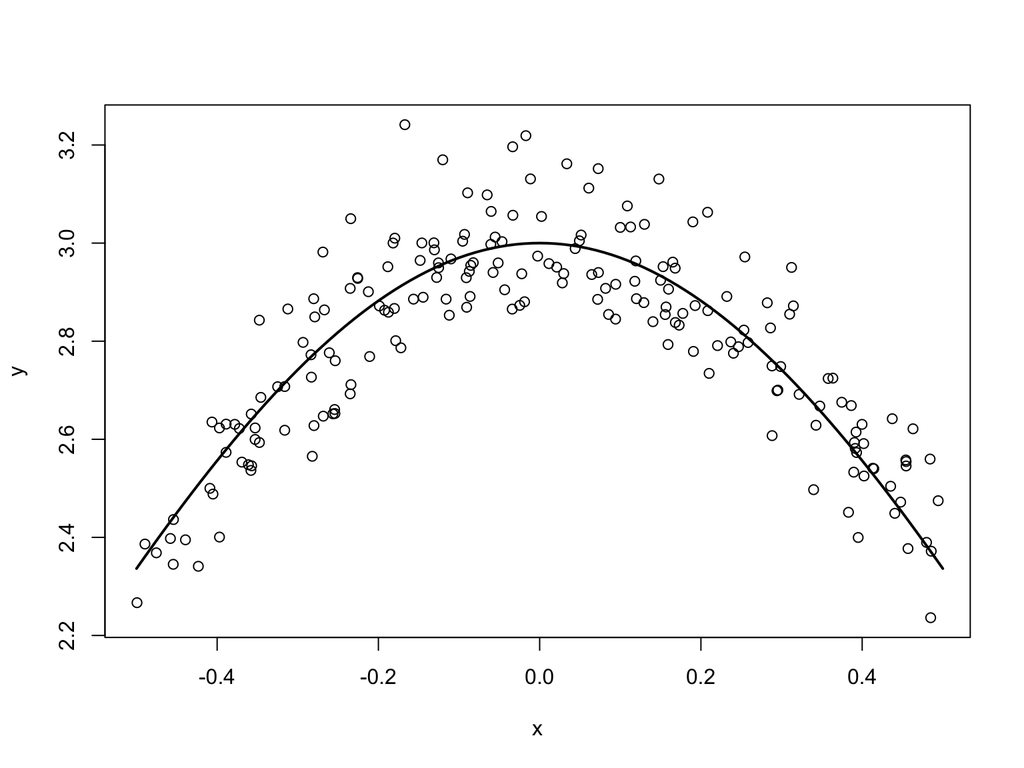

```r
set.seed(123)

n <- 200 # sample size

x <- sort(runif(n, -0.5, 0.5)) # design point
eps <- rnorm(n, sd = 0.1) # random error

m <- function(x){ # real function
  3 * exp(-x^2)
}

y <- m(x) + eps # y

plot(x, y)
curve(m, -0.5, 0.5, lwd=2, add = T)
```

# Performance of Rule of Thumb

```r
library(locpol)
K = EpaK
p <- 1 # local linear
h_rot = thumbBw(x, y, deg = p, kernel = K) # rule of thumb
print(h_rot)
```

```
## [1] 0.1229284
```

```r
# local linear regression
loclin <- locPolSmootherC(x, y, xeval = x, bw = h_rot, kernel = K, deg = p)
y_hat = loclin$beta0
```

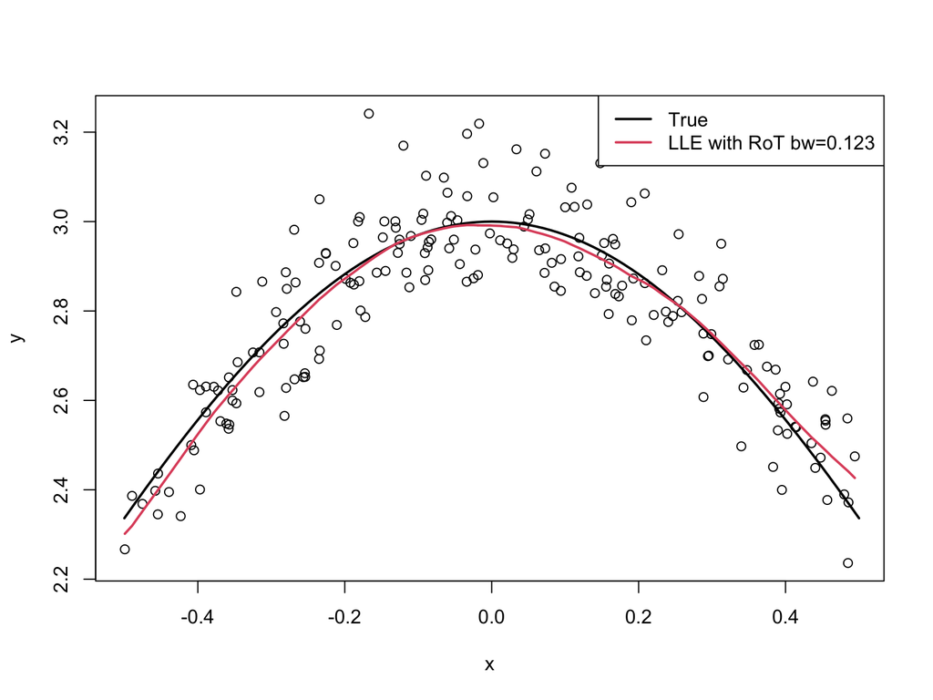

```r
plot(x, y)
curve(m, -0.5, 0.5, lwd=2, add = T)
lines(x, y_hat, col = 2, lwd = 2)
legend('topright',  legend = c('True', paste0('LLE with RoT bw=',round(h_rot, digits = 3))),
       lwd=2, lty = 1, col = 1:2)
```

# Leave-One-Out Cross-Validation (LOOCV)

Suppose $p = 1, \nu = 0$ (using local linear to estimate the function itself)

- **Risk**: $R(h)=\mathbb E \left[\frac{1}{n}\sum_{i=1}^n \{\hat m(x_i)-m(x_i)\}^2 \right]$
- **Training Error**: $\frac{1}{n}\sum_{i=1}^n \{Y_i - \hat m(x_i)\}^2$

Training error often *underestimates* the Risk!

- **Definition**. The **Leave-One-Out Cross-Validation score** is defined by
  $$CV(h)=\hat R(h)=\frac{1}{n}\sum_{i=1}^n \{Y_i - \hat m_{(-i)}(x_i)\}^2,$$
  where $\hat m_{(-i)}$ is the estimator obtained by omitting the $i$-th pair $(x_i, Y_i)$ with bandwidth $h$.
- **Intuition**.
  $$\begin{aligned}
  \mathbb{E}\left(Y_{i}-\hat{m}_{(-i)}\left(x_{i}\right)\right)^{2} &=\mathbb{E}\left(Y_{i}-m\left(x_{i}\right)+m\left(x_{i}\right)-\hat{m}_{(-i)}\left(x_{i}\right)\right)^{2} \\
  &=\sigma^{2}+\mathbb{E}\left(m\left(x_{i}\right)-\hat{m}_{(-i)}\left(x_{i}\right)\right)^{2} \\
  & \approx \sigma^{2}+\mathbb{E}\left(m\left(x_{i}\right)-\hat{m}\left(x_{i}\right)\right)^{2}.
  \end{aligned}$$
  Hence $E{ (\hat R)}\approx R + \sigma^2$.

# LOOCV Score for Linear Smoother

- **Theorem 1**. Suppose $\hat m(x)=\sum_i \ell_i(x)Y_i$, then LOOCV score can be written as
  $$\hat{R}(h)=\frac{1}{n} \sum_{i=1}^{n}\left(\frac{Y_{i}-\hat{m}\left(x_{i}\right)}{1-L_{i i}}\right)^{2},$$
  where $L_{ii}=\ell_i(x_i)$.
- If we denote
  $$\begin{aligned}
  &\hat m = \big(\hat m(x_1),\dots, \hat m(x_n)\big)^\top\in\mathbb{R}^n,\\
  &Y=(Y_1,\dots, Y_n)\in\mathbb{R}^n,\\
  &L = \big(\ell_j(x_i)\big)_{1\le i,j \le n} \in \mathbb{R}^{n\times n},
  \end{aligned}$$
  then
  $$\hat m = LY$$

# Proof of the Theorem 1

*Proof*. From the property of linear smoother, we know that
$$\hat m_{(-i)}(x)=\sum_{j=1}^n \ell_{j,(-i)}(x)Y_j,$$
where
$$\ell_{j,(-i)}(x)=\left\{\begin{array}{ll}
0 & \text { if } j=i \\
\frac{\ell_{j}(x)}{\sum_{k \neq i} \ell_{k}(x)} & \text { if } j \neq i.
\end{array}\right.$$
Then, we should have
$$\hat m_{(-i)}(x_i)=\frac{1}{1-L_{ii}}\sum_{j=1\\j\ne i}^n \ell_{j}(x_i)Y_j=\frac{1}{1-L_{ii}}\sum_{j=1\\j\ne i}^n L_{ij}Y_j.$$
It follows that
$$\hat m_{(-i)}(x_i) = L_{ii}\hat m_{(-i)}(x_i) + \hat m(x_i) - L_{ii} Y_i.$$
From which we conclude
$$Y_i - \hat m_{(-i)}(x_i) =Y_i- \hat m(x_i) + L_{ii} \big(Y_i - \hat m_{(-i)}(x_i) \big),$$
and thus
$$Y_i - \hat m_{(-i)}(x_i) = \frac{Y_i- \hat m(x_i)}{1-L_{ii}}.$$
Consequently,
$$\hat{R}(h)=\frac{1}{n}\sum_{i=1}^n \big(Y_i - \hat m_{(-i)}(x_i)\big)^2=\frac{1}{n} \sum_{i=1}^{n}\left(\frac{Y_{i}-\hat{m}\left(x_{i}\right)}{1-L_{i i}}\right)^{2}. \blacksquare$$

# LOOCV for Bandwidth Selection

**Procedures**

- Choose a bandwidth grid $h_1,\dots, h_m$ from, for example, $[0.01n^{-1/5}, 100n^{-1/5}]$
- Compute $CV(h_1),\dots, CV(h_m)$
- Let $h_{cv}=\arg\min_{h\in\{h_1,\dots,h_m \}}CV(h)$

**Generalized cross-validation (GCV)**
$$GCV(h)=\frac{1}{n} \sum_{i=1}^{n}\left(\frac{Y_{i}-\hat{m}\left(x_{i}\right)}{1-trace(L)/n}\right)^{2}$$

# Performance of LOOCV

```r
library(locpol)
K = EpaK
p <- 1 # local linear
h_cv = regCVBwSelC(x, y, deg = p, kernel = K) # leave-one-out cross-validation
print(h_cv)
```

```
## [1] 0.1392815
```

```r
# local linear regression
loclin <- locPolSmootherC(x, y, xeval = x, bw = h_cv, kernel = K, deg = p)
y_hat2 = loclin$beta0
```

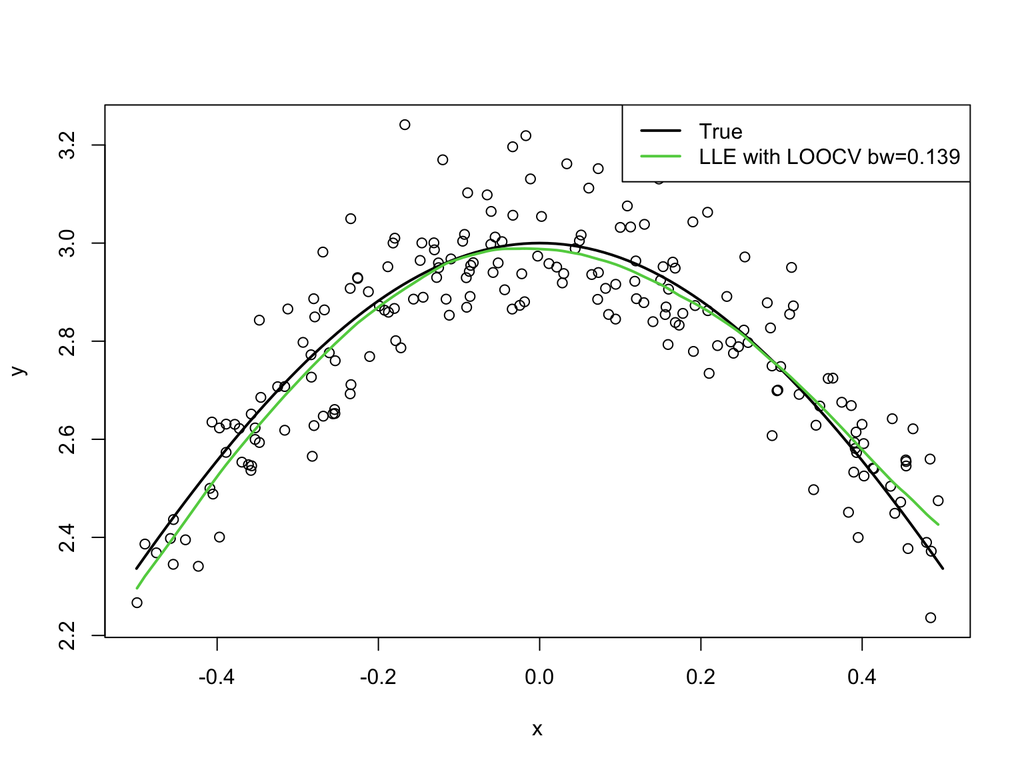

```r
plot(x, y)
curve(m, -0.5, 0.5, lwd=2, add = T)

lines(x, y_hat2, col = 3, lwd = 2)
legend('topright',  legend = c('True', paste0('LLE with LOOCV bw=',round(h_cv, digits = 3))),
       lwd=2, lty = 1, col = c(1,3))
```

# Difficulty of Bandwidth Selection

Bandwidth selection criterion
$$B(h)=\Xi(n, h) \times \frac{1}{n} \sum_{i=1}^{n}\left(Y_{i}-\hat{m}\left(x_{i}\right)\right)^{2}$$
Suppose

- $\hat h = \arg\min B(h)$
- $\hat h_0 = \arg\min L(h)$, where $L(h) = \frac{1}{n} \sum_{i=1}^{n}\left(\hat{m}\left(x_{i}\right)-m(x_i)\right)^{2}$
- $h_0 = \arg\min R(h)$, where $R(h)=\mathbb E (L(h))$

Hardle et al. (1988) proved that $\hat h, \hat h_0, h_0$ are all of order $O(n^{-1/5})$, and under some assumptions
$$\begin{aligned}
n^{3 / 10}\left(\widehat{h}-\widehat{h}_{0}\right) & \leadsto N\left(0, \sigma_{1}^{2}\right), \\
n^{3 / 10}\left(h_{0}-\widehat{h}_{0}\right) & \leadsto N\left(0, \sigma_{2}^{2}\right),
\end{aligned}$$
where $\sigma_1,\sigma_2$ are two positive constants.

Then, we should have
$$\begin{aligned}
\frac{\widehat{h}-\hat{h}_{0}}{\widehat{h}_{0}}=O_{P}\left(\frac{n^{1 / 5}}{n^{3 / 10}}\right)=O_{P}\left(n^{-1 / 10}\right),\\
\frac{\hat{h}_{0}-h_{0}}{h_{0}}=O_{P}\left(\frac{n^{1 / 5}}{n^{3 / 10}}\right)=O_{P}\left(n^{-1 / 10}\right).
\end{aligned}$$

# Review of Local Polynomial Modelling

- Model: $Y=m(X)+\sigma(X)\varepsilon$, where $m(\cdot)$ is the unknown function
- Local Polynomial: Fitting a polynomial *locally*
  $$\min_{\beta_0,\dotsm\beta_p} \sum_{i=1}^n \Big\{Y_i-\sum_{j=0}^p\beta_j(X_j-x_0)^j \Big\}^2K_h(X_i - x_0),$$
  where $K_h(\cdot)=K(\cdot/h)/h$ and $K(\cdot)$ is the *kernel* function.

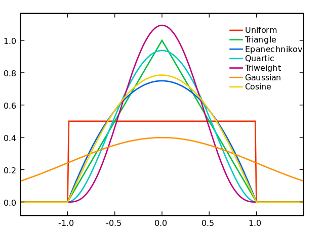

Plots of various kernels

- **Bias and Variance**
- Boundary effects
- Order of polynomial ($p-\nu$ being **odd** is better!)
- Minimax efficiency
- **Asymptotic normality**
- Bandwidth Selection

Thank you!